# Homework 9

By 19086

2019-12-10

## Question 1 (Exercises 11.1)

The natural logarithm and exponential functions are inverses of each other, so that mathematically $log(exp x) = exp(log x) = x$. Show by example that this property does not hold exactly in computer arithmetic. Does the identity hold with near equality? (See all.equal.)

## Solution 1

R provides the function *all.equal* to check for near equality of two *R* objects. In a logical expression, use *isTRUE* to obtain a logical value.

Firstly, we can generate $100$ sample points from $[0.1, 2]$ uniformly, and check the identity.

```r
n <- 100
x <- seq(0.1, 2, length.out=n)
alpha <- unlist(base::lapply(x, function(x) ifelse(log(exp(x)) == exp(log(x)), 1, 0)))
cat("Ratio of equalities", sum(alpha)/n)
```

```
## Ratio of equalities 0.76
```

It means that there are about 24% $x$’s do not support $log(exp x) = exp(log x) = x$ in computer arithmetic.

Secondly,

```r
n <- 100
x <- seq(0.1, 2, length.out=n)
alpha <- unlist(base::lapply(x, function(x) ifelse(isTRUE(all.equal(log(exp(x)), exp(log(x)))), 1, 0)))
cat("Ratio of equalities", sum(alpha)/n)
```

```
## Ratio of equalities 1
```

We can see that the identity hold with near equality.

## Question 2 (Exercises 11.5)

Write a function to solve the equation
$$\begin{equation}
\frac{2 \Gamma\left(\frac{k}{2}\right)}{\sqrt{\pi(k-1)} \Gamma\left(\frac{k-1}{2}\right)}
\int_{0}^{c_{k-1}}\left(1+\frac{u^{2}}{k-1}\right)^{-k / 2} d u
=
\frac{2 \Gamma\left(\frac{k+1}{2}\right)}{\sqrt{\pi k} \Gamma\left(\frac{k}{2}\right)}
\int_{0}^{c_{k}}\left(1+\frac{u^{2}}{k}\right)^{-(k+1) / 2} d u
\end{equation}$$
for $a$, where
$$\begin{equation}
c_{k}=\sqrt{\frac{a^{2} k}{k+1-a^{2}}}
\end{equation}$$
Compare the solutions with the points $A(k)$ in Exercise 11.4

### Exercise 11.4

Find the intersection points $A(k)$ in $(0, \sqrt{k})$ of the curves
$$\begin{equation}
S_{k-1}(a) = P\left(t(k-1)>\sqrt{\frac{a^{2}(k-1)}{k-a^{2}}}\right)
\end{equation}$$
and
$$\begin{equation}
S_{k}(a) = P\left(t(k)>\sqrt{\frac{a^{2} k}{k+1-a^{2}}}\right)
\end{equation}$$
for $k = 4 : 25, 100, 500, 1000$, where $t(k)$ is a Student $t$ random variable with $k$ degrees of freedom. (These intersection points determine the critical values for a $t$-test for scale-mixture errors proposed by Szekely [260].)

## Solution 2

The equation contains integration calculation and ratio of large gamma function.

I will use *integrate* function to calculate the integration as following

```r
# this is integrate function
myfun <- function(u, k){
  (1 + u^2/k)^(-(k+1) / 2)
}
integrate(myfun, lower=0, upper=ck, k=k)
```

And use *lgamma* to calculate the ratio of large gamma function
$$\begin{equation}
\frac{\Gamma\left(\frac{k+1}{2}\right)}{\Gamma\left(\frac{k}{2}\right)}
\end{equation}$$

```r
exp(lgamma((k+1)/2) - lgamma(k/2))
```

To see how the result depends on $k$ and find the root of the equation, we can write the follwoing code using *uniroot* function.

```r
k.loop <- c(4:25, 100, 500, 1000)

myfun1 <- function(a, k.cur){
  ck_1 <- sqrt(a^2 * (k.cur-1) / (k.cur - a^2))
  ck <- sqrt(a^2 * k.cur / (k.cur + 1- a^2))
  fun.left <- 2 * exp(lgamma(k.cur/2) - lgamma((k.cur-1)/2)) / sqrt(pi * (k.cur-1)) * integrate(function(u, k) (1 + u^2/k)^(-(k+1) / 2), lower=0, upper=ck_1, k=k.cur-1)$value
  fun.right <- 2 * exp(lgamma((k.cur+1)/2) - lgamma(k.cur/2)) / sqrt(pi * k.cur) * integrate(function(u, k) (1 + u^2/k)^(-(k+1) / 2), lower=0, upper=ck, k=k.cur)$value
  fun.left - fun.right
}

# Record result 1
out1 <- numeric(length(k.loop))
ii <- 1
for (k in k.loop) {
  if (k>25){
    out1[ii] <- uniroot(myfun1, lower=0.01, upper=sqrt(k-1), k.cur=k)$root
  } else {
    out1[ii] <- uniroot(myfun1, lower=0.01*sqrt(k-1), upper=0.99*sqrt(k-1), k.cur=k)$root
  }

  ii <- ii + 1
}
```

Next, we compare the result with Exercise 11.4.

```r
intersection <- function (k) {
  s.k.minus.one <- function (a) {
    1-pt(sqrt(a^2 * (k - 1) / (k - a^2)), df = k-1)
  } #the function of S_{k-1}(a)
  s.k <- function (a) {
    1-pt(sqrt(a^2 * k / (k + 1 - a^2)), df = k)
  } #the function of S_{k}(a)
  f <- function (a) {
    s.k(a) - s.k.minus.one(a)
  } #the root of f is the intersection points

  eps <- .Machine$double.eps^0.5
  return(uniroot(f, interval = c(eps, sqrt(k)-eps))$root) #find the intersection points A(k) in (0,sqrt(k))
}

k <- c(4:25, 100, 500, 1000)
out2 <- sapply(k, function (k) {
  intersection(k)
  })
```

Print the result

```r
out <- cbind(k=k, Method1=out1, Method2=out2)
print(out)
```

```
##          k   Method1   Method2
##  [1,]    4  1.492102  1.492103
##  [2,]    5  1.533557  1.533549
##  [3,]    6  1.562774  1.562768
##  [4,]    7  1.584422  1.584421
##  [5,]    8  1.601211  1.601182
##  [6,]    9  1.614524  1.614517
##  [7,]   10  1.625382  1.625356
##  [8,]   11  1.634408  1.634387
##  [9,]   12  1.642022  1.642006
## [10,]   13  1.648541  1.648569
## [11,]   14  1.654174  1.654176
## [12,]   15  1.659097  1.659106
## [13,]   16  1.663436  1.663448
## [14,]   17  1.667299  1.667294
## [15,]   18  1.670724  1.670731
## [16,]   19  1.673819  1.673839
## [17,]   20  1.676613  1.676588
## [18,]   21  1.679153  1.679139
## [19,]   22  1.681471  1.681461
## [20,]   23  1.683584  4.795832
## [21,]   24  1.685519  4.898979
## [22,]   25  1.687340  5.000000
## [23,]  100  1.720578 10.000000
## [24,]  500 21.278932 22.360680
## [25,] 1000  1.730903 31.622777
```

## Question 3 (A-B-O blood type problem)

Let the three alleles be A, B, and O with allele frequencies $p$, $q$, and $r$. The $6$ genotype frequencies under HWE and complete counts are as follows.

| Genotype | AA | BB | OO | AO | BO | AB | Sum |
| --- | --- | --- | --- | --- | --- | --- | --- |
| Frequency | $p^2$ | $q^2$ | $r^2$ | $2pr$ | $2qr$ | $2pq$ | $1$ |
| Count | $n_{AA}$ | $n_{BB}$ | $n_{OO}$ | $n_{AO}$ | $n_{BO}$ | $n_{AB}$ | $n$ |

Observed data: $n_{A\cdot} = n_{AA} + n_{AO} = 28$ (A-type), $n_{B·} = n_{BB} + n_{BO} = 24$ (B-type), $n_{OO} = 41$ (O-type), $n_{AB} = 70$ (AB-type).

1. Use EM algorithm to solve MLE of $p$ and $q$ (consider missing data $n_{AA}$ and $n_{BB}$).
2. Show that the log-maximum likelihood values in M-steps are increasing via line plot.

## Solution 3

### Idea of EM

The EM (Expectation Maximization) algorithm is a general optimization method that is often applied to find maximum likelihood estimates when data are incomplete.

1. Start with an initial estimate of the target parameter, and then alternate the E (expectation) step and M (maximization) step.
2. In the E step compute the conditional expectation of the objective function (usually a loglikelihood function) given the observed data and current parameter estimates.
3. In the M step, the conditional expectation is maximized with respect to the target parameter.
4. Update the estimates and iteratively repeat the E and M steps until the algorithm converges according to some criterion.

Because of the observed data, we can rewrite the table as:

| Genotype | Frequency | Count |
| --- | --- | --- |
| AA | $p^2$ | $n_{AA}$ |
| BB | $q^2$ | $n_{BB}$ |
| OO | $r^2$ | $n_{OO}=41$ |
| AO | $2pr$ | $n_{AO}=28-n_{AA}$ |
| BO | $2qr$ | $n_{BO}=24-n_{BB}$ |
| AB | $2pq$ | $n_{AB}=70$ |
|  | $1$ | $n=163$ |

We can write code as following.

```r
# Write the log-likelihood function
lnL <- function(p, q, nA = 28, nB = 24, nOO = 41, nAB = 70) {
  r = 1 - p - q
  nA * log(p^2 + 2*p*r) + nB * log(q^2 + 2 * q * r) + 2 * nOO * log(r) + nAB * log(2 * p * q)
}

# Write the E-M function
EM <- function (p, q, nA = 28, nB = 24, nOO = 41, nAB = 70, debug = FALSE) {

  # Evaluate the likelihood using initial estimates
  llk <- lnL(p, q, nA, nB, nOO, nAB)

  # Count the number of iterations so far
  iter <- 1
  # Vector for Record log-likelihood value
  llk.rec <- numeric(0)

  # Loop until convergence
  while (TRUE)
  {
    # Estimate the frequency for allele O
    r = 1 - p - q

    # Record llk
    llk.rec <- c(llk.rec, llk)

    # First we carry out the E-step

    # The counts for genotypes O/O and A/B are effectively observed
    # Estimate the counts for the other genotypes
    nAA <- nA * p / (p + 2*r)
    nAO <- nA - nAA
    nBB <- nB * q / (q + 2*r)
    nBO <- nB - nBB

    # Print debugging information
    if (debug)
    {
      cat("Round #", iter, "lnLikelihood = ", llk, "\n")
      cat("    Allele frequencies: p = ", p, ", q = ", q, ", r = ", r, "\n")
      cat("    Genotype counts:    nAA = ", nAA, ", nAO = ", nAO, ", nBB = ", nBB,
          ", nBO = ", nBO, "\n")
    }

    # Then the M-step
    p <- (2 * nAA + nAO + nAB) / (2 * (nA + nB + nOO + nAB))
    q <- (2 * nBB + nBO + nAB) / (2 * (nA + nB + nOO + nAB))

    # Then check for convergence
    llk1 <- lnL(p, q, nA, nB, nOO, nAB)

    if (abs(llk1 - llk) < (abs(llk) + abs(llk1)) * 1e-6)
      break

    # Otherwise keep going
    llk <- llk1
    iter <- iter + 1
  }
  list(p = p, q = q, r=1-p-q, llk.rec=llk.rec)
}

# Set the initial estimate of the target parameters, then run the E-M function.
out <- EM(0.3, 0.25, nA = 28, nB = 24, nOO = 41, nAB = 70, debug = TRUE)
```

```
## Round # 1 lnLikelihood =  -256.799
##     Allele frequencies: p =  0.3 , q =  0.25 , r =  0.45
##     Genotype counts:    nAA =  7 , nAO =  21 , nBB =  5.217391 , nBO =  18.78261
## Round # 2 lnLikelihood =  -251.9918
##     Allele frequencies: p =  0.3220859 , q =  0.3043478 , r =  0.3735663
##     Genotype counts:    nAA =  8.434577 , nAO =  19.56542 , nBB =  6.946728 , nBO =  17.05327
## Round # 3 lnLikelihood =  -251.9161
##     Allele frequencies: p =  0.3264864 , q =  0.3096525 , r =  0.363861
##     Genotype counts:    nAA =  8.671549 , nAO =  19.32845 , nBB =  7.163913 , nBO =  16.83609
## Round # 4 lnLikelihood =  -251.9146
##     Allele frequencies: p =  0.3272133 , q =  0.3103188 , r =  0.3624679
##     Genotype counts:    nAA =  8.707866 , nAO =  19.29213 , nBB =  7.194028 , nBO =  16.80597
```

```r
cat("p=", out$p, "\tq=", out$q, "\tr=", out$r)
```

```
## p= 0.3273247     q= 0.3104111    r= 0.3622641
```

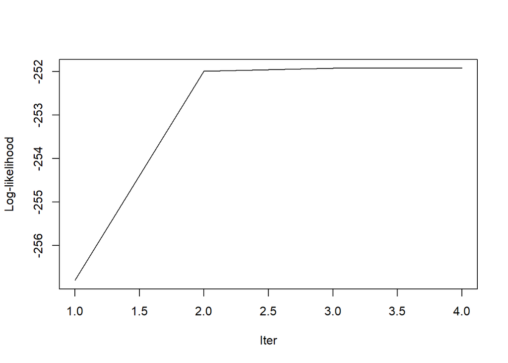

```r
plot(1:length(out$llk.rec), out$llk.rec, "l", xlab="Iter", ylab="Log-likelihood")
```